# 제20대 대통령 선거 데이터 과학

대한민국 주요선거 정당수 추세에 나타난 민심의 변화

2022-01-02

중앙선거관리위원회에서 공공데이터포털에 API 형태로 다양한 데이터를 제공하고 있습니다. 이중 대선, 총선, 지선에 참여한 정당수가 너무 많아 관심을 가지고 일주일 분석할 결과 2013년이 통진당 해산등으로 극도로 정당설립과 활동이 위축되었던 시점이였던 사실과 더불어 2016년은 이전 수준을 회복했다면 2017년 이후 정당수 변화를 통한 확연한 민심의 변화를 데이터를 통해 확인할 수 있었습니다.

# 1 주요 선거별 정당수 변화추세

2017년 대통령선거는 사상초유의 대통령 탄핵이라는 어마어마한 변화도 있었지만 이전과 확연히 달라진 민심의 변화를 파악할 수 있다. 2016년까지 국회의원선거에 출마하는 후보가 많아 상대적으로 대통령선거나 지방선거에 등록된 정당의 수가 적었으나 2017년 대선을 기점으로 국회의원선거, 지방선거, 대통령선거에 등록된 정당이 폭발적으로 증가하고 있다.

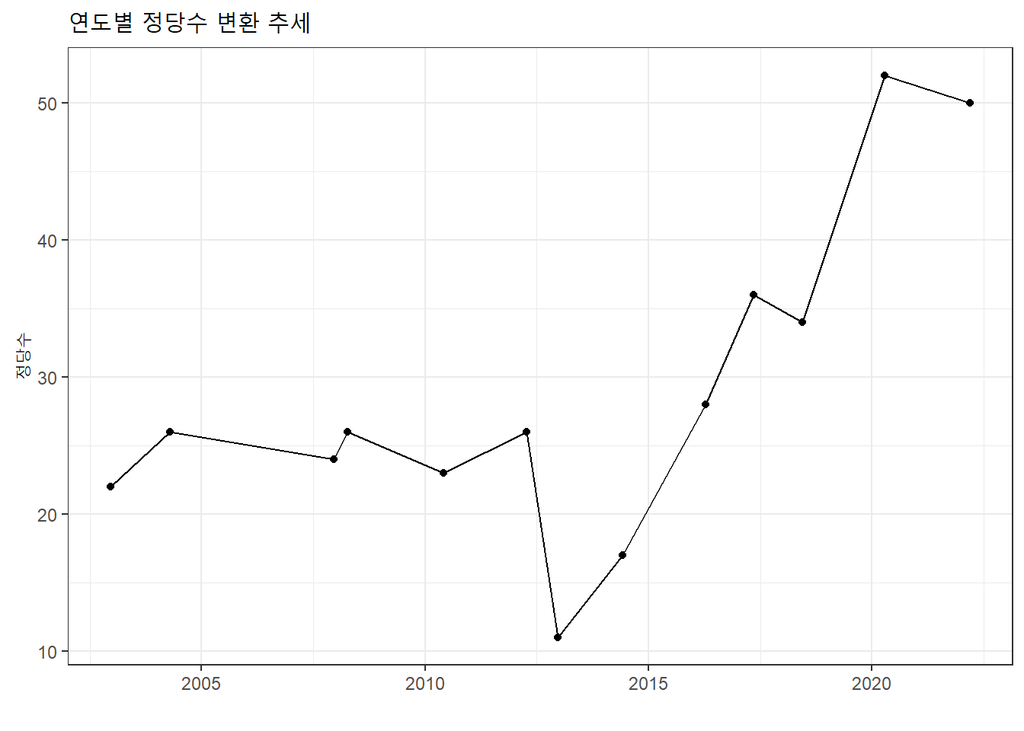

중앙선거관리위원회에서 원천데이터를 공공데이터 포털에 제공하고 있고 다양한 데이터 중 선거별 정당정보를 함께 API 형태로 제공하고 있어 이를 다시 주요 선거별(대선, 총선, 지선)로 나눠봐도 선거유형에 관계없이 모두 선거에 참여하는 정당의 숫자가 폭발적으로 늘고 있다는 것을 확인할 수 있다.

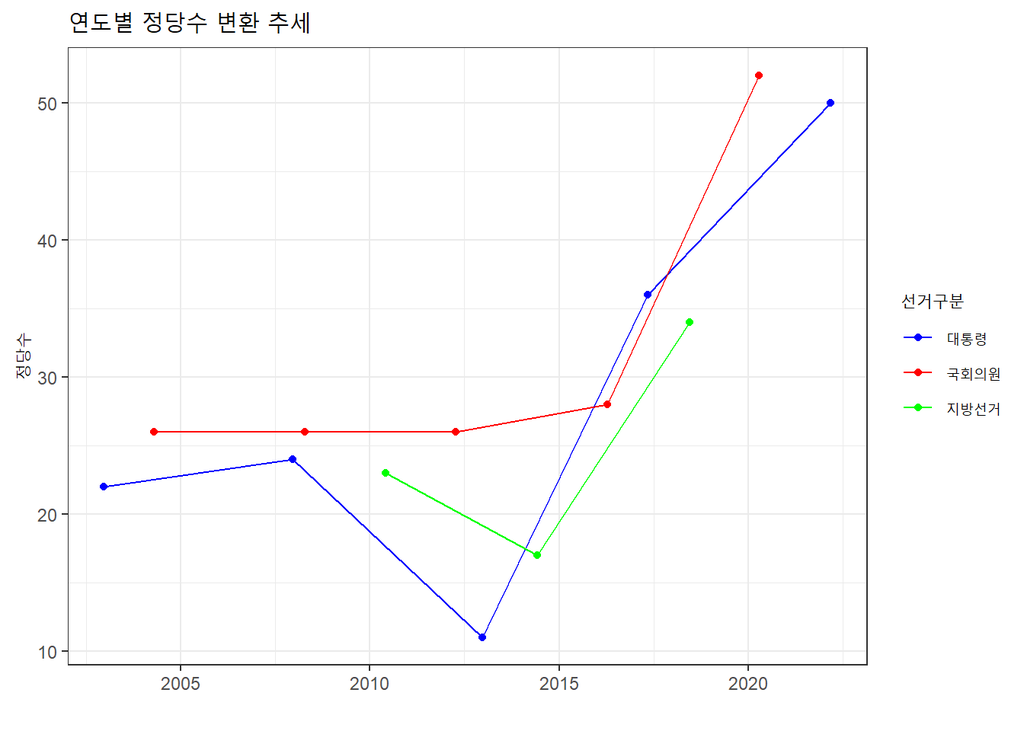

2013년 통합진보당해산 심판이 청구되어 2014년 선고가 내려지면서 2012년 전후 정당설립과 활동에 위축이 제18대 대선 전후 정당수가 뚜렸한 감소가 있었던 것으로 보이며 이후 제20대 국회의원선거를 거치면서 이전 정당수를 통해 이전 정당활동을 회복한 것으로 보이며 이후 2017년 실시된 제19대 대통령선거를 거치면서 확연한 민심의 변화가 정당수에 나타나고 있다.

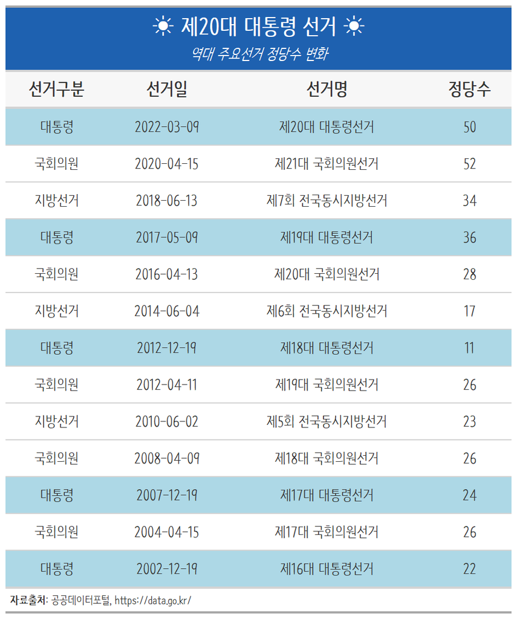